# Final Project

Brendan Gillespy and Justin Thoms

5/11/2020

## Introduction

College Football has become the backbone of many college athletics programs. With greater revenue than the next 14 college sports *combined*, NCAA Football regularly draws more fans and viewership than other major professional sports leagues.

Which game statistic is the best indicator of a win?

## Project Setup

```r
library(tidyverse)
library(cvTools)
library(randomForest)
```

For this project, we will be making use of the following libraries:

- `tidyverse` will be used for tidying and manipulating data.frames
- `cvTools` will help us create folds in our data for predictive modeling
- `randomForest` will allow us to use Random Forest modeling on our data

## Data Management and Organization

As our data was separated by year, we needed to combine our tables. However, due to the combination of the now-massive number of entities and attributes mapped for each entity, particularly within our Team-Game dataset, we needed to only select the attributes that we need for our work. To do this, we

1. Create some functions that we’ll use for data organization
2. Import all of our datasets
3. Combine all the separate datasets
4. Mutate new attributes we need for our data

```r
#/---------------------------------------------------------------------------------------------------------------/#


## Functions in this section deal with selecting only data we need from large dataframes


rushPassSelect <- function(df){
  df %>%
    select(`Team Code`, Yards)
}

# This function will only select the data we need for our analysis and to create more attributes from the teamGameStats dataframe
teamGameStatsSelect <- function (df){
  df %>%
    select(`Game Code`, `Team Code`, `Points`, `Rush Yard`, `Pass Yard`, `Kickoff Ret Yard`, `Punt Ret Yard`, `Misc Ret Yard`, `Int Ret Yard`, `Fum Ret Yard`, `Pass Int`, `Fumble Lost`, `Punt`, `Penalty`, `1st Down Rush`, `1st Down Pass`, `1st Down Penalty`, `Time Of Possession`)
}


#/---------------------------------------------------------------------------------------------------------------/#

## Functions in this section deal with adding attributes to the teamGameStats dataframe that require ##

# This function will add the 'yardsAgainst' attribute to the given dataframe
mutateYardsAgainst <- function(df){

  findYards <- function(gameCode, teamCode){
    opponentYards <- df %>%
      filter(`Game Code` == gameCode & `Team Code` != teamCode) %>%
      select(`Rush Yard`,`Pass Yard`,`Kickoff Ret Yard`,`Punt Ret Yard`,`Misc Ret Yard`,`Int Ret Yard`,`Fum Ret Yard`)
    as.double(opponentYards[1,1]+opponentYards[1,2]+opponentYards[1,3]+opponentYards[1,4]+opponentYards[1,5]+opponentYards[1,6]+opponentYards[1,7])
  }

  colNum <- ncol(df) + 1

  for(i in 1:nrow(df)){
    df[i,colNum] = findYards(as.character(df[i,"Game Code"]), as.double(df[i,"Team Code"]))
  }

  names(df)[colNum] <- "yardsAgainst"

  df
}


# This function will add the 'opponentPoints' attrubute to the given dataframe
mutatePointsAgainst <- function(df){

  findPoints <- function(gameCode, teamCode){
    opponentPoints <- df %>%
      filter(`Game Code` == gameCode & `Team Code` != teamCode) %>%
      select(Points)
    as.double(opponentPoints[1,1])
  }

  colNum <- ncol(df) + 1

  for(i in 1:nrow(df)){
    df[i,colNum] = findPoints(as.character(df[i,"Game Code"]), as.double(df[i,"Team Code"]))
  }

  names(df)[colNum] <- "opponentPoints"

  df
}


#This function will find the 'turnoverDiff' attribute to the given dataframe
mutateTurnoverDiff <- function(df){


  findTurnovers <- function(gameCode, teamCode){
    opponentTurnovers <- df %>%
      setNames(make.names(names(.), unique = TRUE)) %>%
      filter(Game.Code == gameCode & Team.Code != teamCode) %>%
      select(Pass.Int, Fumble.Lost, Punt)
    as.double(opponentTurnovers[1,1] + opponentTurnovers[1,2], + opponentTurnovers[1,3])
  }

  colNum <- ncol(df) + 1

  for(i in 1:nrow(df)){
    df[i, colNum] = (df[i, "Pass Int"] + df[i, "Fumble Lost"] + df[i, "Punt"]) - findTurnovers(as.character(df[i,"Game Code"]), as.double(df[i,"Team Code"]))

  }

  names(df)[colNum] <- "turnoverDiff"

  df
}


#This function will find the 'timeOfPossessionDifferential' for the given dataframe
mutateTOPDiff <- function(df){

  findTOP <- function(gameCode, teamCode){
    opponentTOP <- df %>%
      setNames(make.names(names(.), unique = TRUE)) %>%
      filter(Game.Code == gameCode & Team.Code != teamCode) %>%
      select(Time.Of.Possession)
    as.double(opponentTOP[1,1])
  }

  colNum <- ncol(df) + 1

  for(i in 1:nrow(df)){
    df[i,colNum] = df[i, "Time Of Possession"] - findTOP(as.character(df[i,"Game Code"]), as.double(df[i,"Team Code"]))
  }

  names(df)[colNum] <- "timeOfPossesionDifferential"

  df
}

#/---------------------------------------------------------------------------------------------------------------/#
```

```r
#/---------------------------------------------------------------------------------------------------------------/#

## These tables hold data about the games - who's home, what the attendance is, etc. ##

#Importing every year's game data
games2005 <- read_csv("college-football-statistics/cfbstats-com-2005-1-5-0/game.csv")
games2006 <- read_csv("college-football-statistics/cfbstats-com-2006-1-5-0/game.csv")
games2007 <- read_csv("college-football-statistics/cfbstats-com-2007-1-5-0/game.csv")
games2008 <- read_csv("college-football-statistics/cfbstats-com-2008-1-5-0/game.csv")
games2009 <- read_csv("college-football-statistics/cfbstats-com-2009-1-5-0/game.csv")
games2010 <- read_csv("college-football-statistics/cfbstats-com-2010-1-5-0/game.csv")
games2011 <- read_csv("college-football-statistics/cfbstats-com-2011-1-5-0/game.csv")
games2012 <- read_csv("college-football-statistics/cfbstats-com-2012-1-5-4/game.csv")
games2013 <- read_csv("college-football-statistics/cfbstats-com-2013-1-5-20/game.csv")


# rbinding the dataframes into one, long dataframe
games <- rbind(games2005, games2006, games2007, games2008, games2009, games2010, games2011, games2012, games2013)


#/---------------------------------------------------------------------------------------------------------------/#

## These dataframes hold data about how each team did in every game. It's most of the data we use in this project. ##

# Importing every year's data frame, making sure to filter out the data we don't need
teamGameStats2005 <- read_csv("college-football-statistics/cfbstats-com-2005-1-5-0/team-game-statistics.csv") %>% teamGameStatsSelect()
teamGameStats2006 <- read_csv("college-football-statistics/cfbstats-com-2006-1-5-0/team-game-statistics.csv") %>% teamGameStatsSelect()
teamGameStats2007 <- read_csv("college-football-statistics/cfbstats-com-2007-1-5-0/team-game-statistics.csv") %>% teamGameStatsSelect()
teamGameStats2008 <- read_csv("college-football-statistics/cfbstats-com-2008-1-5-0/team-game-statistics.csv") %>% teamGameStatsSelect()
teamGameStats2009 <- read_csv("college-football-statistics/cfbstats-com-2009-1-5-0/team-game-statistics.csv") %>% teamGameStatsSelect()
teamGameStats2010 <- read_csv("college-football-statistics/cfbstats-com-2010-1-5-0/team-game-statistics.csv") %>% teamGameStatsSelect()
teamGameStats2011 <- read_csv("college-football-statistics/cfbstats-com-2011-1-5-0/team-game-statistics.csv") %>% teamGameStatsSelect()
teamGameStats2012 <- read_csv("college-football-statistics/cfbstats-com-2012-1-5-4/team-game-statistics.csv") %>% teamGameStatsSelect()
teamGameStats2013 <- read_csv("college-football-statistics/cfbstats-com-2013-1-5-20/team-game-statistics.csv") %>% teamGameStatsSelect()

# rbinding the the frames together to get one, longer data frame
teamGameStats <- rbind(teamGameStats2013, teamGameStats2012, teamGameStats2011, teamGameStats2010, teamGameStats2009, teamGameStats2008, teamGameStats2007, teamGameStats2006, teamGameStats2005)


# Creating new attributes for teamGameStats using the data we already have
teamGameStats <- teamGameStats %>%

  # 'yardsFor' will give us the sum of all yards during a game for the team
  mutate(yardsFor=`Rush Yard`+`Pass Yard`+`Kickoff Ret Yard`+`Punt Ret Yard`+`Misc Ret Yard`+`Int Ret Yard`+`Fum Ret Yard`) %>%

  # 'firstDowns' will tell us how many first downs a team got during each game
  mutate(firstDowns=(`1st Down Rush` + `1st Down Pass` + `1st Down Penalty`)) %>%

  # 'home' will tell us whether or not the team was home during that game
  inner_join(games, by="Game Code") %>%
  mutate(home=(`Team Code` == `Home Team Code` & Site=="TEAM"))


teamGameStats <- mutateYardsAgainst(teamGameStats) %>% mutatePointsAgainst() %>% mutateTurnoverDiff() %>% mutateTOPDiff()

teamGameStats <- teamGameStats %>%
  mutate(win=(opponentPoints<Points))


#/---------------------------------------------------------------------------------------------------------------/#

## This dataframes hold per-carry rushing data, including yards per attempt, and which school it was done for ##

rushing2005 <- read_csv("college-football-statistics/cfbstats-com-2005-1-5-0/rush.csv") %>% rushPassSelect()
rushing2006 <- read_csv("college-football-statistics/cfbstats-com-2006-1-5-0/rush.csv") %>% rushPassSelect()
rushing2007 <- read_csv("college-football-statistics/cfbstats-com-2007-1-5-0/rush.csv") %>% rushPassSelect()
rushing2008 <- read_csv("college-football-statistics/cfbstats-com-2008-1-5-0/rush.csv") %>% rushPassSelect()
rushing2009 <- read_csv("college-football-statistics/cfbstats-com-2009-1-5-0/rush.csv") %>% rushPassSelect()
rushing2010 <- read_csv("college-football-statistics/cfbstats-com-2010-1-5-0/rush.csv") %>% rushPassSelect()
rushing2011 <- read_csv("college-football-statistics/cfbstats-com-2011-1-5-0/rush.csv") %>% rushPassSelect()
rushing2012 <- read_csv("college-football-statistics/cfbstats-com-2012-1-5-4/rush.csv") %>% rushPassSelect()
rushing2013 <- read_csv("college-football-statistics/cfbstats-com-2013-1-5-20/rush.csv") %>% rushPassSelect()

rushing <- rbind(rushing2005, rushing2006, rushing2007, rushing2008, rushing2009, rushing2010, rushing2011, rushing2012, rushing2013)


#/---------------------------------------------------------------------------------------------------------------/#

## These dataframes hold per-pass passing data, including yards for each attempt, and the school it was done for ##

passing2005 <- read_csv("college-football-statistics/cfbstats-com-2005-1-5-0/pass.csv") %>% rushPassSelect()
passing2006 <- read_csv("college-football-statistics/cfbstats-com-2006-1-5-0/pass.csv") %>% rushPassSelect()
passing2007 <- read_csv("college-football-statistics/cfbstats-com-2007-1-5-0/pass.csv") %>% rushPassSelect()
passing2008 <- read_csv("college-football-statistics/cfbstats-com-2008-1-5-0/pass.csv") %>% rushPassSelect()
passing2009 <- read_csv("college-football-statistics/cfbstats-com-2009-1-5-0/pass.csv") %>% rushPassSelect()
passing2010 <- read_csv("college-football-statistics/cfbstats-com-2010-1-5-0/pass.csv") %>% rushPassSelect()
passing2011 <- read_csv("college-football-statistics/cfbstats-com-2011-1-5-0/pass.csv") %>% rushPassSelect()
passing2012 <- read_csv("college-football-statistics/cfbstats-com-2012-1-5-4/pass.csv") %>% rushPassSelect()
passing2013 <- read_csv("college-football-statistics/cfbstats-com-2013-1-5-20/pass.csv") %>% rushPassSelect()

passing <- rbind(passing2005, passing2006, passing2007, passing2008, passing2009, passing2010, passing2011, passing2012, passing2013)


#/---------------------------------------------------------------------------------------------------------------/#

## These dataframes hold some meta-data about each team, including which conference they're in and what their school name is. ##

teams2005 <- read_csv("college-football-statistics/cfbstats-com-2005-1-5-0/team.csv")
teams2006 <- read_csv("college-football-statistics/cfbstats-com-2006-1-5-0/team.csv")
teams2007 <- read_csv("college-football-statistics/cfbstats-com-2007-1-5-0/team.csv")
teams2008 <- read_csv("college-football-statistics/cfbstats-com-2008-1-5-0/team.csv")
teams2009 <- read_csv("college-football-statistics/cfbstats-com-2009-1-5-0/team.csv")
teams2010 <- read_csv("college-football-statistics/cfbstats-com-2010-1-5-0/team.csv")
teams2011 <- read_csv("college-football-statistics/cfbstats-com-2011-1-5-0/team.csv")
teams2012 <- read_csv("college-football-statistics/cfbstats-com-2012-1-5-4/team.csv")
teams2013 <- read_csv("college-football-statistics/cfbstats-com-2013-1-5-20/team.csv")

teams <- rbind(teams2005, teams2006, teams2007, teams2008, teams2009, teams2010, teams2011, teams2012, teams2013)
teams <- teams[match(unique(teams$`Team Code`), teams$`Team Code`),]

#/---------------------------------------------------------------------------------------------------------------/#

## These dataframes hold some data about conferences, including conference-type, and name. ##

conference2005 <- read_csv("college-football-statistics/cfbstats-com-2005-1-5-0/conference.csv")
conference2006 <- read_csv("college-football-statistics/cfbstats-com-2006-1-5-0/conference.csv")
conference2007 <- read_csv("college-football-statistics/cfbstats-com-2007-1-5-0/conference.csv")
conference2008 <- read_csv("college-football-statistics/cfbstats-com-2008-1-5-0/conference.csv")
conference2009 <- read_csv("college-football-statistics/cfbstats-com-2009-1-5-0/conference.csv")
conference2010 <- read_csv("college-football-statistics/cfbstats-com-2010-1-5-0/conference.csv")
conference2011 <- read_csv("college-football-statistics/cfbstats-com-2011-1-5-0/conference.csv")
conference2012 <- read_csv("college-football-statistics/cfbstats-com-2012-1-5-4/conference.csv")
conference2013 <- read_csv("college-football-statistics/cfbstats-com-2013-1-5-20/conference.csv")

conference <- rbind(conference2013, conference2012, conference2011, conference2010, conference2009, conference2008, conference2007, conference2006, conference2005)
conference <- conference[match(unique(conference$`Conference Code`),conference$`Conference Code`),]

#/---------------------------------------------------------------------------------------------------------------/#

## This code creates a new dataframe, containing the sum of total wins by each school ##

seasonWins <- teamGameStats %>%
  filter(win == TRUE) %>%
  group_by(`Team Code`) %>%
  summarize(Wins=n())
```

We had challenges through each of these steps. For starters, when we combined our dataframes, after importing, we found that dataframes are limited to a certain size within R. This meant that, particularly with `teamGameStats`, `rush`, and `pass`, we needed to select only the data we needed for our graphs. To do this, we directly selected the columns we needed for the year-by-year frames, and then rbound them together.

To get our yards against, time of possession differential, turnover differential, and determine who won, we needed to access the data from the opposing team’s game data. To this, we made a function that found the opposing team by Game and Team ID and returned it. Then, we created a for loop to go through each entity and append it as a new entity.

Finally, as conferences were realigned between 2010-2014 we needed to make sure that we had the correct final conference of each team. Beyond this, as this data set only included FBS games, and many FBS do one FCS game each season, we needed to make sure that each team’s name and conference data was stored only once. For this, we rbound each table together and then removed any entities that were repeated.

## Interesting Visualizations

To get familiar with our dataset, and to make some interesting observations about our data, we decided to do some exploratory data analysis.

### PPG vs Total Yards

Rationally speaking, if you have more yards, that should correlate to more times that your team has marched down to the end-zone, or at least gotten close. In this graph, we can see that this theory generally holds, following a linear regression. This proves that there is a correlation between Yards per Game and Points per Game.

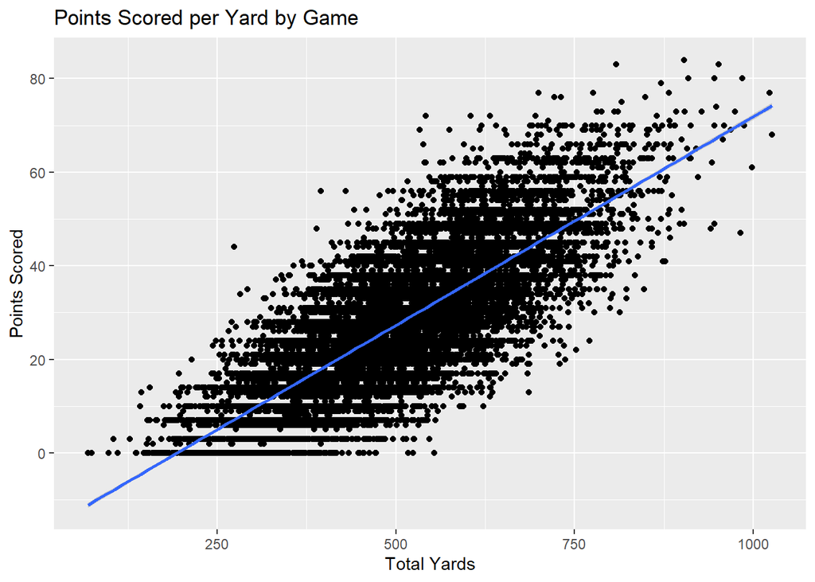

```r
# See points scored per game per each number of total yardage
teamGameStats %>%
  ggplot((aes(x=yardsFor, y=Points))) +
  geom_point() +
  geom_smooth(method=lm) +
  labs(x="Total Yards",
       y="Points Scored",
       title = "Points Scored per Yard by Game")
```

### Wins For Team by Conference

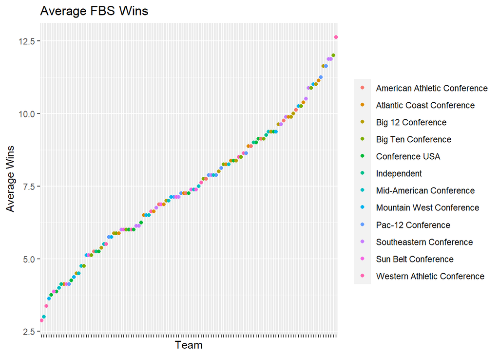

```r
# See total wins for each team, seperated by conference
seasonWins %>%
  inner_join(teams, by="Team Code") %>%
  inner_join(conference, by="Conference Code") %>%
  filter(Subdivision=="FBS") %>%
  ggplot(aes(x=reorder(factor(Name.x), Wins), y=(Wins/8), color=Name.y)) +
  geom_point() +
  labs(x="Team",
       y="Average Wins",
       title = "Average FBS Wins") +
  theme(axis.text.x=element_blank(),
        legend.title = element_blank())
```

After this, we wanted to see who the winningest teams across our dataset and found Boise State on top. With Boise State’s highest all-time winning percentage, and strong run during 2005-2013, it’s highest wins placement makes a ton of sense. Likewise, Ohio State and Alabama are both in the top 5 highest winning percentages of all time, and both had dominant 21st-century runs and National Championship Wins.

```r
seasonWins %>%
  inner_join(teams, by="Team Code") %>%
  inner_join(conference, by="Conference Code") %>%
  filter(Subdivision=="FBS") %>%
  arrange(desc(Wins)) %>%
  slice(1:5) %>%
  inner_join(teams, by="Team Code") %>%
  select(Name, Wins)
```

```
## # A tibble: 5 x 2
##   Name         Wins
##   <chr>       <int>
## 1 Boise State   101
## 2 Ohio State     96
## 3 Alabama        95
## 4 LSU            95
## 5 Oklahoma       93
```

### Rushing Yards per Attempt

Next, we wanted to see how effective different programs were on run plays. To do this, we grouped 6 historically great college football teams and compared their rushing yards per play with a violin plot. For this, we can notice that every school has a couple of break-away plays on the run, which shouldn’t affect our view of each school’s effectiveness on the run. However, if we look at Ohio State’s distribution, we can see they are significantly more effective in the 10-15 yard attempt range, showcasing their stronger running ability. This makes sense, especially with star running backs like Ezekiel Elliot, Carlos Hyde, and Beanie Wells.

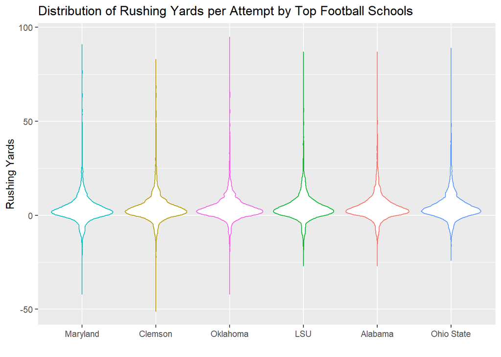

```r
# See the distribution of rushing yards per attempt by several top football schools

rushing %>%
  filter(`Team Code` == 392 | `Team Code` == 8 | `Team Code` == 518 | `Team Code` == 147 | `Team Code` == 365 | `Team Code` == 522) %>%
  inner_join(teams2013, by="Team Code") %>%
  ggplot(aes(x=reorder(factor(Name), Yards), y=Yards, color=Name)) +
    geom_violin() +
    labs(x="",
         y="Rushing Yards",
         title = "Distribution of Rushing Yards per Attempt by Top Football Schools") +
    theme(legend.position = "none")
```

### Passing Yards per Attempt

Much like the rushing yards per attempt, this graph shows the distribution of passing yards per attempt for the same top schools listed in the rushing attempts. While, much like the rushing graph, there are extreme outliers that shouldn’t be a real factor, we can still find schools that stand out in their passing efficiency. In particular, we see that Oklahoma has a much higher 5-10 yard passing efficiency and that LSU has a significantly less dense passing efficiency. Oklahoma’s passing excellence makes a lot of sense, particularly in the air-raid style offenses that many Big 12 programs use. LSU, on the other hand, is surprising, considering their multiple SEC championships, 2 National Championship appearances, and 1 National Championship win in this span.

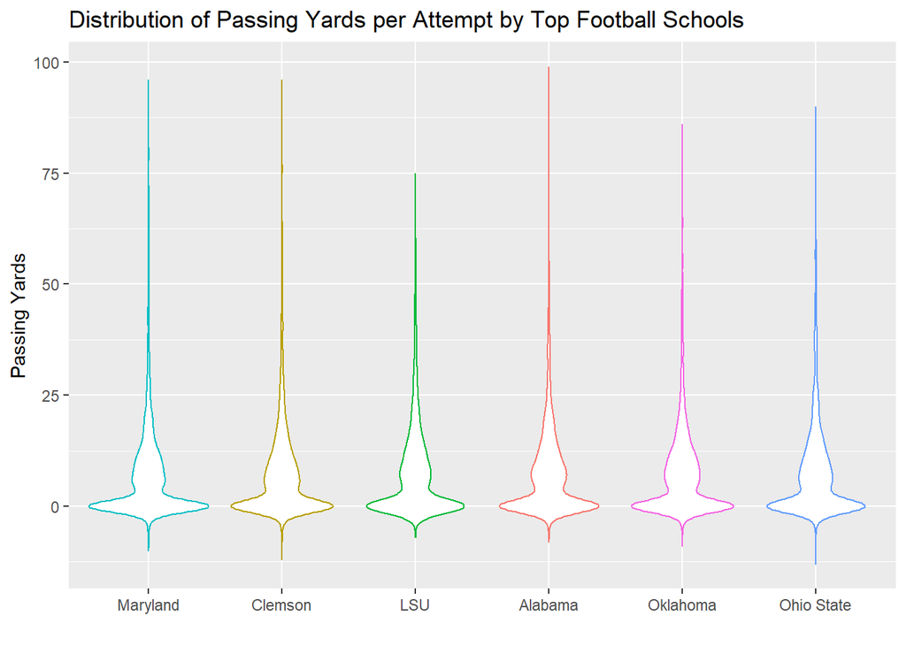

```r
# See the distribution of passing yards per attempt by top football schools
passing %>%
  inner_join(teams, by="Team Code") %>%
  filter(`Team Code` == 392 | `Team Code` == 8 | `Team Code` == 518 | `Team Code` == 147 | `Team Code` == 365 | `Team Code` == 522) %>%
  ggplot(aes(x=reorder(factor(Name), Yards), y=Yards, color=Name)) +
  labs(x="",
       y="Passing Yards",
       title = "Distribution of Passing Yards per Attempt by Top Football Schools") +
  geom_violin() +
  theme(legend.position="none")
```

## What variable influences win the most?

To determine the viability of each variable as a predictor for wins, we will first visualize the relationship of each variable vs. wins and later use regression to see if it can be used to correctly identify games as wins or losses.

### Yards For

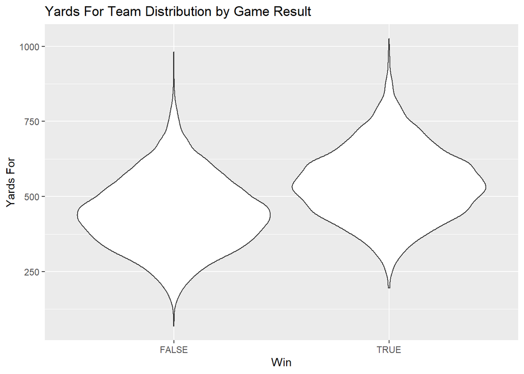

```r
teamGameStats %>%
  ggplot(aes(x=win, y=yardsFor)) +
  geom_violin() +
  labs(x="Win",
       y="Yards For",
       title="Yards For Team Distribution by Game Result")
```

As expected, yards plays a big role in a team’s ability to win the game. Reaching the red zone or endzone more than your opponent to score more points means the winning team will most likely have more yards by the end of the game. This variable would be a good predictor of the winner of a game.

### Yards Against

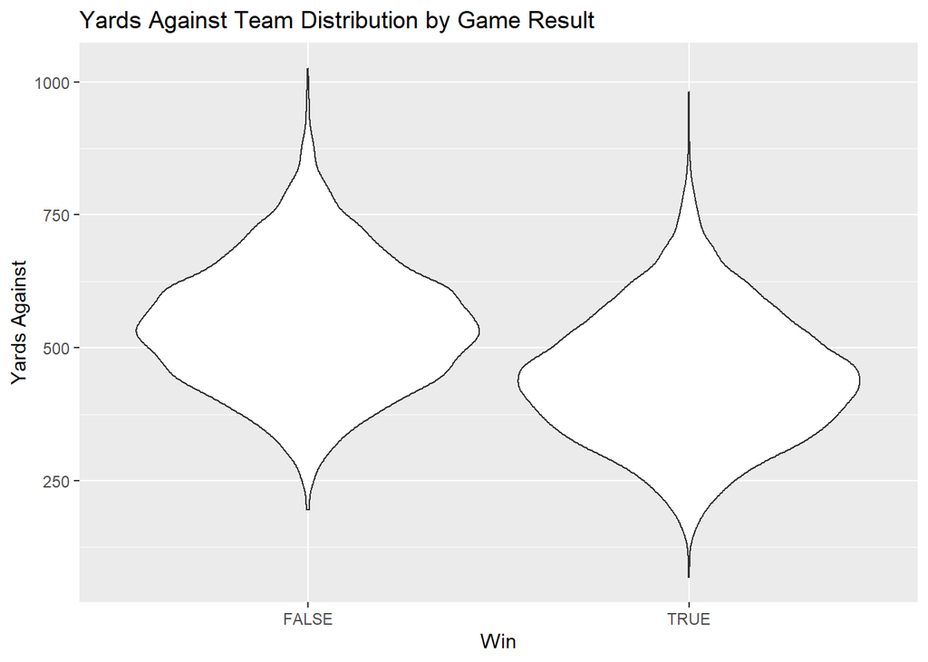

```r
teamGameStats %>%
  ggplot(aes(x=win, y=yardsAgainst)) +
  geom_violin() +
  labs(x="Win",
       y="Yards Against",
       title="Yards Against Team Distribution by Game Result")
```

Similarly to Yards For, yards against shows that a team needs to have its opponent end up with fewer yards by the end of the game, meaning that they will have fewer chances to score. This is also a valid predictor for wins.

### Turnovers

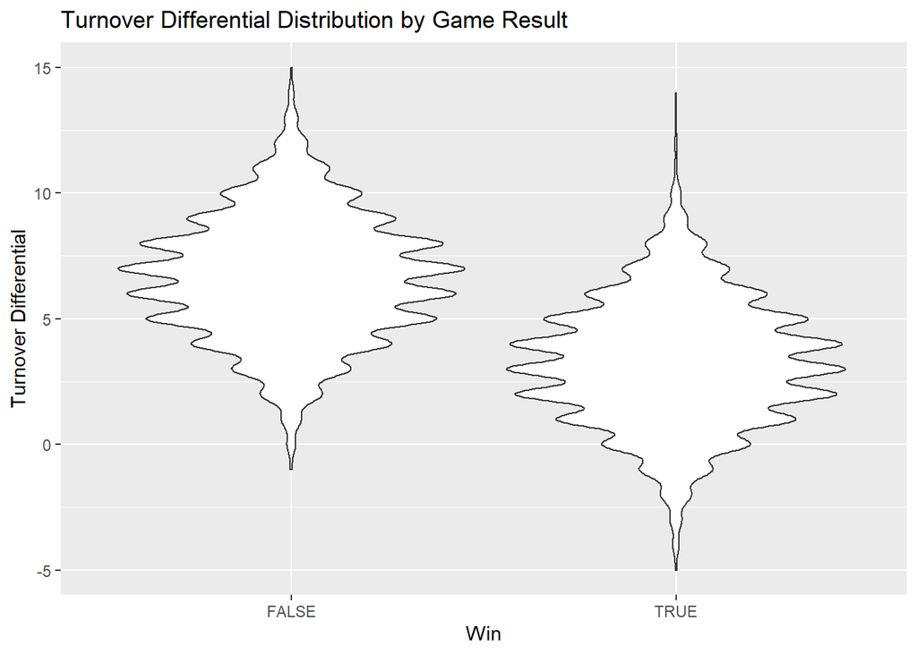

```r
teamGameStats %>%
  ggplot(aes(x=win, y=turnoverDiff)) +
  geom_violin() +
  labs(x="Win",
       y="Turnover Differential",
       title="Turnover Differential Distribution by Game Result")
```

Turnovers have good potential to be a predictor of wins. Teams that turn over the ball less compared to their opponent have more chances to score. However, there seems to be more spread in the distribution of turnover differential for games won, so it may be harder to predict with.

### Home Field Advantage

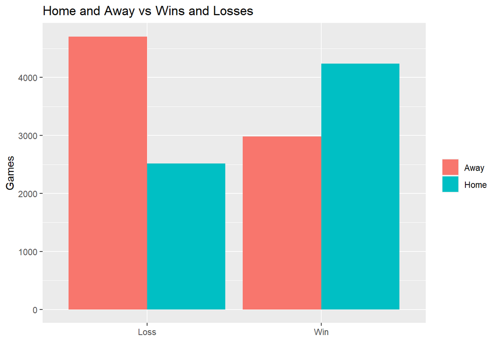

```r
teamGameStats %>%
  group_by(home, win) %>%
  summarize(count=n()) %>%
  ggplot(aes(x=win, y=count, fill=home)) +
  geom_bar(stat="identity", position=position_dodge()) +
  scale_x_discrete(label=c("Loss", "Win")) +
  scale_fill_discrete(labels=c("Away", "Home")) +
  theme(legend.title=element_blank()) +
  labs(x="",
       y="Games",
       title="Home and Away vs Wins and Losses")
```

This variable was one of the most interesting to analyze. According to popular belief, “Home Field Advantage” is when the home team supposedly has a higher chance to win the game. This could be due to more home team fans cheering them on, or not having to travel far for the game. Whatever differences this causes in the player’s attitude towards the game is reflected in this plot. Teams that are home seem to win more often than not, and teams that away seem to lose much more than they win.

### First Downs

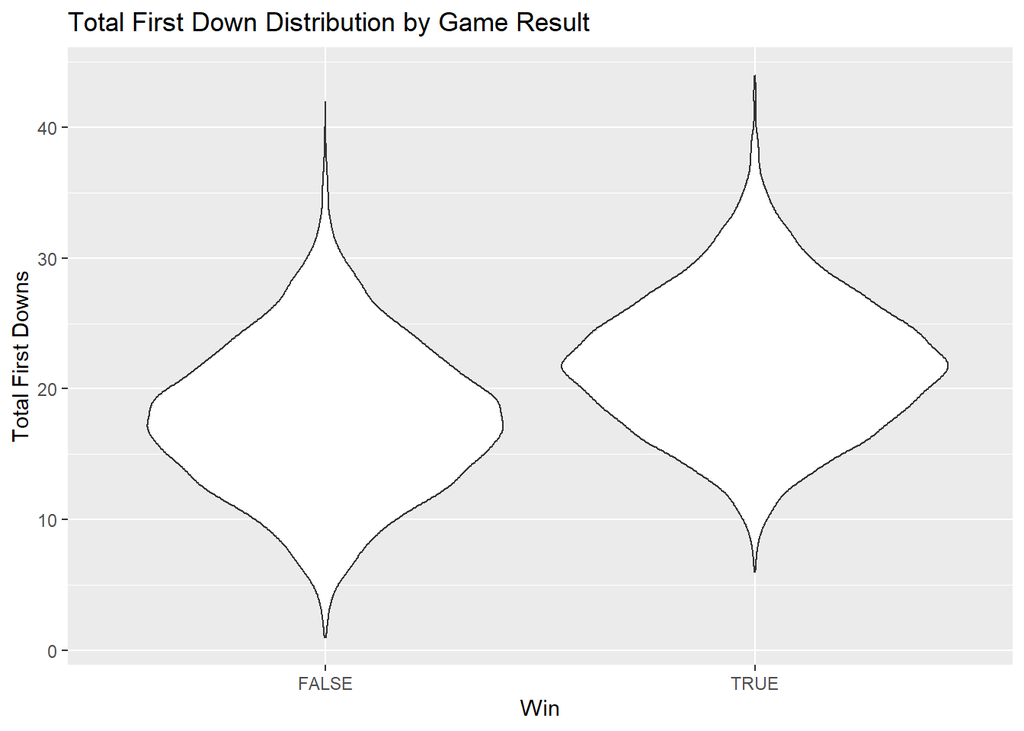

```r
teamGameStats %>%
  ggplot(aes(x=win, y=firstDowns)) +
  geom_violin() +
  labs(x="Win",
       y="Total First Downs",
       title="Total First Down Distribution by Game Result")
```

Amount of first downs in a game is another expected side effect of a winning team. The more first downs a team gets, the more chances they have at getting more yards, and the more chances they have to score. Teams who get more first downs in a game are more likely to win, which could be a good predictor for our model.

### Time of Possession

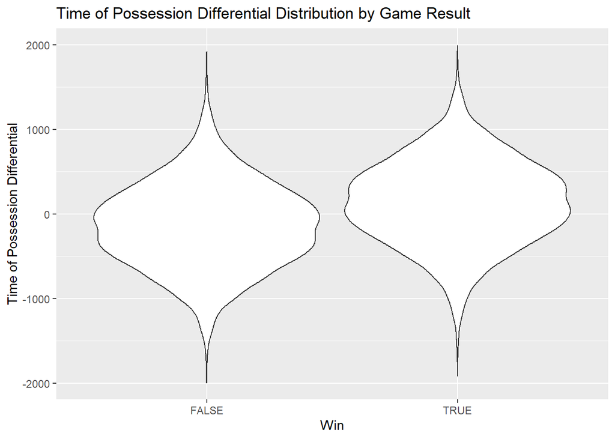

```r
teamGameStats %>%
  ggplot(aes(x=win, y=timeOfPossesionDifferential)) +
  geom_violin() +
  labs(x="Win",
       y="Time of Possession Differential",
       title="Time of Possession Differential Distribution by Game Result")
```

Time of possession includes all of the time a team is on offense. In theory, this could be a predictor based on the fact that the team who has control of the game has the most control over who has possession. The graph mostly follows this assumption, with winning teams having a higher average time of possession.

### Penalties

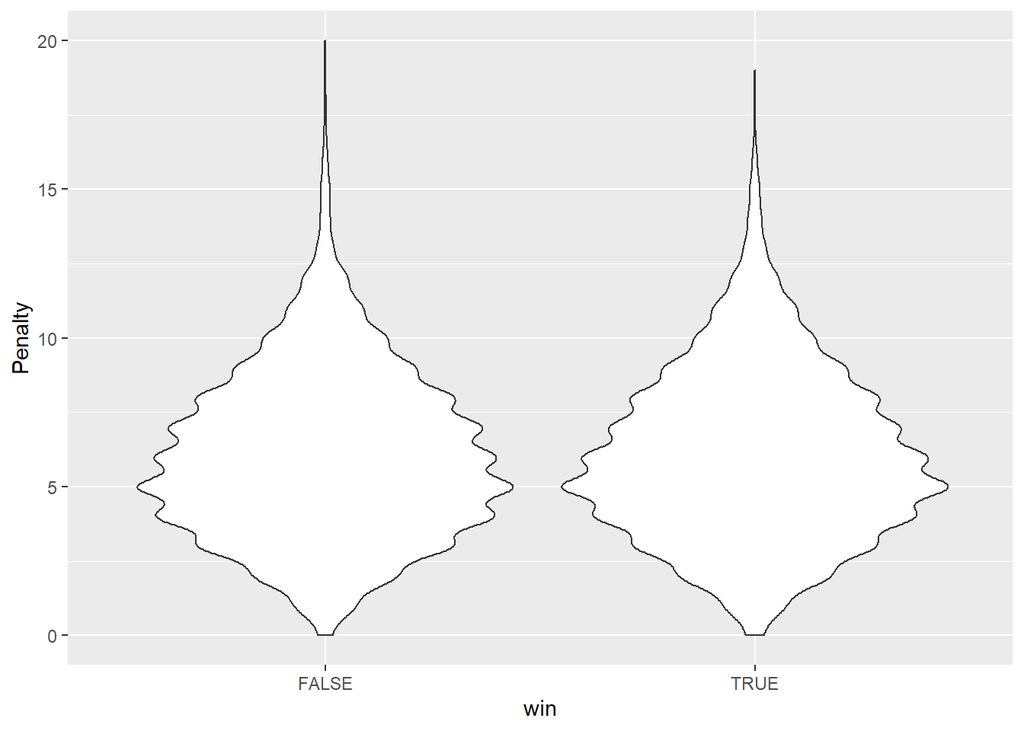

```r
teamGameStats %>%
  inner_join(teams, by="Team Code") %>%
  inner_join(conference, by="Conference Code") %>%
  ggplot(aes(x=win, y=Penalty)) + geom_violin()
```

This plot shows that the distribution of penalties between the winning and losing teams tends to be very similar. Since there is no difference between the number of penalties and winning or losing, this cannot be a valid predictor of whether or not a team will win.

## Choosing a Prediction Model

Each of the prediction types, random forest, and logistic regression, will be tested on all of the valid variables. The smallest error from each of the predictions will determine which prediction model is better for determining the outcome of a game, and how well we can predict a game based on the given variables.

#### Random Forest

```r
regressionData <- teamGameStats %>%
  select(yardsFor, yardsAgainst, turnoverDiff, home, timeOfPossesionDifferential, win)
folds <- cvFolds(n=nrow(regressionData), K = 10)
error <- vector()
for(i in 1:10) {
  fold <- which(folds$which == i)
  model <-  randomForest(win~., data=regressionData[-fold,])
  prediction <- ifelse(predict(model, regressionData[fold,]) > 0.5, 1, 0)
  error <- c(error, mean(regressionData[fold,]$win != prediction))
}
data.frame("Random Forest Error"=mean(error))
```

```
##   Random.Forest.Error
## 1           0.1888504
```

#### Logistic

```r
regressionData <- teamGameStats %>%
  select(yardsFor, yardsAgainst, turnoverDiff, home, timeOfPossesionDifferential, win)
folds <- cvFolds(n=nrow(regressionData), K=10)
error <- vector()
for(i in 1:10) {
  fold <- which(folds$which == i)
  model <- glm(win~., data = regressionData[-fold,], family = "binomial")
  prediction <- ifelse(predict(model, regressionData[fold,]) > 0.5, 1, 0)
  error <- c(error, mean(regressionData[fold,]$win != prediction))
}
data.frame("Logistic Error"=mean(error))
```

```
##   Logistic.Error
## 1      0.1907202
```

## Prediction Error For Each Variable

For each of the previous variables, we will run a regression model using logistic regression to determine whether the variable could be a valid predictor of a team winning a game based on the stats in that category at the end of the game. These predictions can then be used to conclude which is most important in determining the outcome of a game, which will later be used to determine the accuracy of our prediction model.

### Yards For

```r
regressionData <- teamGameStats %>%
  select(yardsFor, win)
folds <- cvFolds(n=nrow(regressionData), K = 10)
error <- vector()
for(i in 1:10) {
  fold <- which(folds$which == i)
  model <- glm(win~., data = regressionData[-fold,], family = "binomial")
  prediction <- ifelse(predict(model, regressionData[fold,]) > 0.5, 1, 0)
  error <- c(error, mean(regressionData[fold,]$win != prediction))
}
data.frame(Error=mean(error))
```

```
##      Error
## 1 0.375277
```

### Yards Against

```r
regressionData <- teamGameStats %>%
  select(yardsAgainst, win)
folds <- cvFolds(n=nrow(regressionData), K = 10)
error <- vector()
for(i in 1:10) {
  fold <- which(folds$which == i)
  model <- glm(win~., data = regressionData[-fold,], family = "binomial")
  prediction <- ifelse(predict(model, regressionData[fold,]) > 0.5, 1, 0)
  error <- c(error, mean(regressionData[fold,]$win != prediction))
}
data.frame(Error=mean(error))
```

```
##       Error
## 1 0.3592798
```

### Turnovers

```r
regressionData <- teamGameStats %>%
  select(turnoverDiff, win)
folds <- cvFolds(n=nrow(regressionData), K = 10)
error <- vector()
for(i in 1:10) {
  fold <- which(folds$which == i)
  model <- glm(win~., data = regressionData[-fold,], family = "binomial")
  prediction <- ifelse(predict(model, regressionData[fold,]) > 0.5, 1, 0)
  error <- c(error, mean(regressionData[fold,]$win != prediction))
}
data.frame(Error=mean(error))
```

```
##       Error
## 1 0.2465374
```

### Home Field Advantage

```r
regressionData <- teamGameStats %>%
  select(home, win)
folds <- cvFolds(n=nrow(regressionData), K = 10)
error <- vector()
for(i in 1:10) {
  fold <- which(folds$which == i)
  model <- glm(win~., data = regressionData[-fold,], family = "binomial")
  prediction <- ifelse(predict(model, regressionData[fold,]) > 0.5, 1, 0)
  error <- c(error, mean(regressionData[fold,]$win != prediction))
}
data.frame(Error=mean(error))
```

```
##       Error
## 1 0.3806787
```

### First Downs

```r
regressionData <- teamGameStats %>%
  select(firstDowns, win)
folds <- cvFolds(n=nrow(regressionData), K = 10)
error <- vector()
for(i in 1:10) {
  fold <- which(folds$which == i)
  model <- glm(win~., data = regressionData[-fold,], family = "binomial")
  prediction <- ifelse(predict(model, regressionData[fold,]) > 0.5, 1, 0)
  error <- c(error, mean(regressionData[fold,]$win != prediction))
}
data.frame(Error=mean(error))
```

```
##       Error
## 1 0.3869114
```

### Time of Possession

```r
regressionData <- teamGameStats %>%
  select(timeOfPossesionDifferential, win)
folds <- cvFolds(n=nrow(regressionData), K = 10)
error <- vector()
for(i in 1:10) {
  fold <- which(folds$which == i)
  model <- glm(win~., data = regressionData[-fold,], family = "binomial")
  prediction <- ifelse(predict(model, regressionData[fold,]) > 0.5, 1, 0)
  error <- c(error, mean(regressionData[fold,]$win != prediction))
}
data.frame(Error=mean(error))
```

```
##       Error
## 1 0.4263158
```

### Penalties

```r
regressionData <- teamGameStats %>%
  select(Penalty, win)
folds <- cvFolds(n=nrow(regressionData), K = 10)
error <- vector()
for(i in 1:10) {
  fold <- which(folds$which == i)
  model <- glm(win~., data = regressionData[-fold,], family = "binomial")
  prediction <- ifelse(predict(model, regressionData[fold,]) > 0.5, 1, 0)
  error <- c(error, mean(regressionData[fold,]$win != prediction))
}
data.frame(Error=mean(error))
```

```
##   Error
## 1   0.5
```

# Conclusion